# 01 - Introduction to Keras and Neural Networks

Dr. Shirin Glander

05./06.07.2018

# Keras

[figure not shown]

### What is Keras and why use it?

Keras is a high-level API written in Python for building and prototyping neural networks. It can be used on top of TensorFlow, Theano or CNTK. Keras is very convenient for fast and easy prototyping of neural networks. It is highly modular and very flexible, so that you can build basically any type of neural network you want. It supports convolutional neural networks and recurrent neural networks, as well as combinations of both. Due to its layer structure, it is highly extensible and can run on CPU or GPU.

The `keras` R package provides an interface to the Python library of Keras, just as the `tensorflow` package provides an interface to TensorFlow. Basically, R creates a conda instance and runs Keras it it, while you can still use all the functionalities of R for plotting, etc. Almost all function names are the same, so models can easily be recreated in Python for deployment.

# Neural Networks

In Machine Learning, neural networks are models that mimic the synapses in human brains. Our brain conveys information via electric signals that travel along the axons of neurons. These cells build a network of inter-connected synapses and dendrites. We learn when new synapses are formed or when they are rearranged. Artificial Neural Networks (ANNs) consist of nodes, that perform calculations and produce an output. Here, information travels via weights and biases to activate connected nodes.

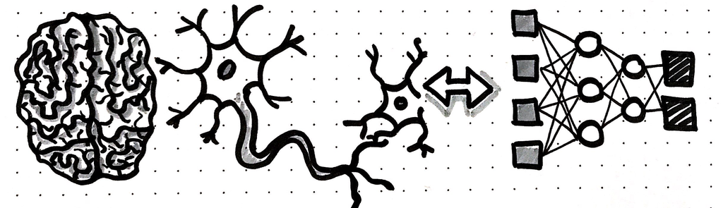

ANNs are not a new concept. Back in the early days of their research, we had so called perceptrons. A simple perceptron consists of inputs (multiplied by weights), biases, an activation function and produces an output. When we add multiple layers of perceptrons, we build so called multi-layer perceptrons (MLP). These were the early stages of ANNs. Between the input and output layer, MLPs have one or more hidden layers.

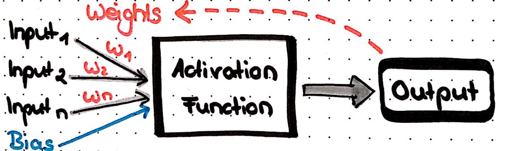

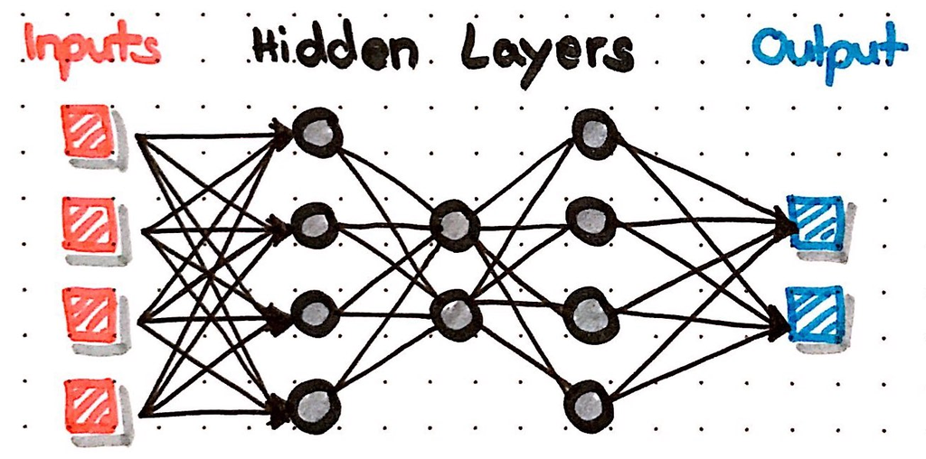

### Activation functions

If we go back to the brain analogy, the activation function determines the threshold at which a neuron fires. Each neuron receives signals from multiple other neurons and only if the sum of all signals is higher than this threshold will it send an electric signal of its own and send the signal along to the next neuron. In neural networks, we also need this switch that determines whether a node is activated (i.e. fires) or not. Without an activation function, we would have a linear function, which has limited power and does not perform well most of the time. Linear models are a good starting point for exploring neural networks. They are relatively fast to train, stable and easier to interpret. But they are also very limited when it comes to representing more complex patterns in data. Therefore, we need to introduce non-linearity in order to solve complex deep neural networks. We can do this by inserting non-linear activation functions into a linear network.

Simple activation functions produce a binary output (1 = fire or 0 = don’t fire). But we can use more complex functions in order to solve complex problems. In ANNs, we take the sum of the inputs multiplied with their weights and apply the activation function in order to produce the output of this layer. The output can either be fed into the next layer or, if it is the last layer, it will be the final output.

The most popular types of activation functions are

- Sigmoid or Logistic
- Tanh or hyperbolic tangent
- ReLu (Rectified Linear Units)

The Sigmoid function is an S-shaped curve that ranges from 0 to 1. It is easy to understand and apply but it has major draw-backs: the vanishing gradient problem and its output isn’t zero centered. This makes the gradient go too far in different directions, which makes optimization harder. Sigmoid also quickly saturates and kills the gradients; and they have slow convergence. Optimization with Tanh is easier because its output is zero centered and ranges from -1 to 1. But it also suffers from the vanishing gradient problem. ReLu is a non-linear function and has a much better convergence rate than Tanh, nor does it suffer from the vanishing gradient problem. Almost all deep learning models use ReLu nowadays. But its limitation is that it should only be used with hidden layers. Sometimes, weight updates can result in a negative feedback loop so that nodes are never activated on any data point again, resulting in dead nodes. To fix this problem another modification was introduced, called Leaky ReLu. It introduces a small slope to keep the updates alive.

# Building Neural Networks

## Classfication with supervised learning

Supervised learning is a sub-field of machine learning and usually deals with classification or regression tasks. In classification, we are predicting labelled instances that are assigned to a given class. By training a classifier on such known instances, we can extrapolate the learned patterns to predict the classes of unlabeled instances. We train a classifier by finding good or even optimal weights and biases. The weights are optimized by comparing the calculated with the expected output. In a classification problem we would compare the predicted output class with the known class and repeat this process until we have achieved a given stopping criterion (e.g. an acceptable error rate).

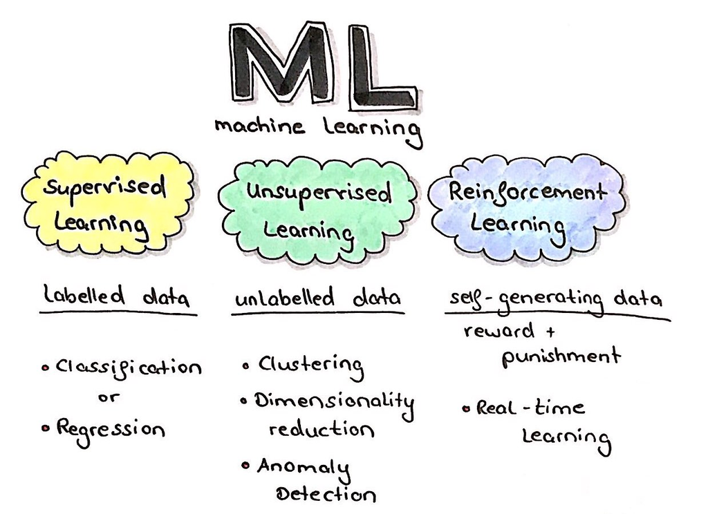

### Finding weights & biases

Training a neural network in essence comes down to a “learning as optimization” problem. The output of every neuron is the weighted sum of all its inputs. The performance of a model, i.e. how well it learned, depends on whether we find good weights and biases. Before training, weights will be set randomly (good practice is to minimize the starting values with zero mean and equal variance and to provide initial weights and bias). During training, we want to optimize the weights to learn the model. There are a few different ways to go about this and one of the most widely used is gradient descent optimization with backpropagation. Backpropagation computes the derivative between points and gradient descent tries to go in the direction of lowest error. In order to understand how it works, we need to understand cross-entropy and loss first.

### Cross-entropy and loss

Cross-entropy or multinomial logistic classification is a measure of relatedness: it measures the distance between two probability distributions and can be used with large numbers of classes. A good model will have low distance (cross-entropy) between the probability distribution of the prediction and the correct class; at the same time, it will have a big distance between the probability distribution and the wrong class. In order to calculate cross-entropy, our model needs to produce probabilities for the output. For this, we can use the softmax function, which turns scores (also called logit scores) into probabilities. Hence we would use a softmax function for output layers of a classification problem to compute the probabilities for the classes.

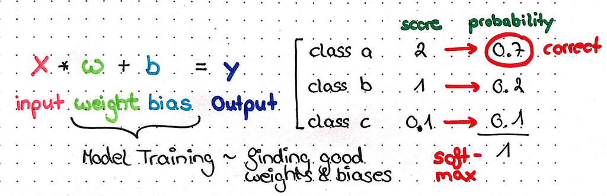

We then use cross-entropy to compare the probability distribution to the one-hot encoded vectors of all classes. One-hot encoding means that for each class, we have a vector representing it as 1 (class == TRUE) or 0 (class == FALSE). These are also sometimes called “dummy variables” and they work as long as the number of classes is not too big. The distance averaged over all training samples is called loss (= average cross-entropy over the entire training set). Loss is a function of weights and biases, so we are trying to minimize the loss. Such a numerical optimization can e.g. be achieved with gradient descent and backpropagation.

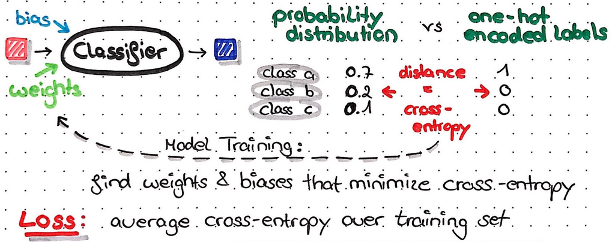

### Backpropagation

Backpropagation is used to calculate the error contribution of each neuron (i.e. of each weight) after a batch of data points is processed. This produces the gradient of the loss function or the difference between the predicted versus known output. The gradient is then used to inform the optimization algorithm, e.g. gradient descent, on how to adjust the weights and biases to reduce the error. Backpropagation is also called backwards propagation of errors because it calculates the output error after the final layer and distributes the information back through preceding layers in a neural network. Because backpropagation requires a known output in order to compare the prediction error to it, it is generally used with supervised learning (although it can also be used in autoencoders, where the output is technically unknown but where we want to minimize the difference between output and input to identify anomalies).

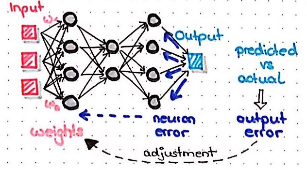

### Gradient descent optimization

Once we have calculated the gradient for each weight with backpropagation, we use it to inform the optimization algorithm that adjusts the weights for the next cycle of training so as to minimize the loss function. By adjusting the weights, we enable our model to learn the representation of the data. The gradient of the weights is calculated by multiplying the difference of predicted vs known output (the error) with the input activation. We then subtract a so called learning rate from the gradient. This learning rate is a given ratio of the weight gradient and can be used to speed up learning. The bigger the learning rate, the faster the training BUT it will also become less accurate. So, we want to choose a learning rate that balances the trade-off between speed and accuracy. Because the error correlates with the weight gradient, the error distribution will look like a parabola with k+1 dimensions (k = number of weights). Training aims to minimize the error, so the weights are updated in the direction of the steepest gradient descent (i.e. in the direction of lowest error). This iterative process is repeated for a given number of cycles, which are called epochs.

A problem with gradient descent and backpropagation is that it doesn’t always find the global minimum of the error function. Because it orients itself anew during each epoch, it has trouble crossing plateaus or it might get stuck in a local minimum.

Scaling gradient descent is another problem because it is iterative and therefore very computationally expensive. This makes it impractical for use with big data and/or big models, as we would use in deep learning. We can speed things up by calculating the average loss of a small random fraction of the samples and treat it as if it were the actual loss of the entire training data and then perform gradient descent on it as before. Used once, this is not a very good method but by repeating it many times with very small steps, the error will balance out and will find an effective solution to our optimization problem. This method is called stochastic gradient descent (SGD). For SGD to work, it is important that we normalize our data (scale to zero mean and equal variance, if possible) and that we use initial random weights and biases that also have small variance. Moreover, we want to make use of two methods that help us find a good minimum of the loss function: momentum and learning rate decay. Momentum uses the running average of the gradient from all previous steps to inform the direction of steepest descent (without momentum, the direction of steepest descent would be determined independently for each step without making use of the information from previous steps). With learning rate decay, we decrease the learning rate over time to achieve better convergence.

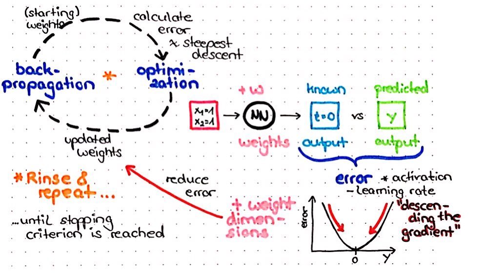

## A general workflow

A general workflow for training a neural network involves understanding and pre-processing the input data, splitting it into training, validation and test data and only then do we actually train models, calculate predictions and model performance measures.

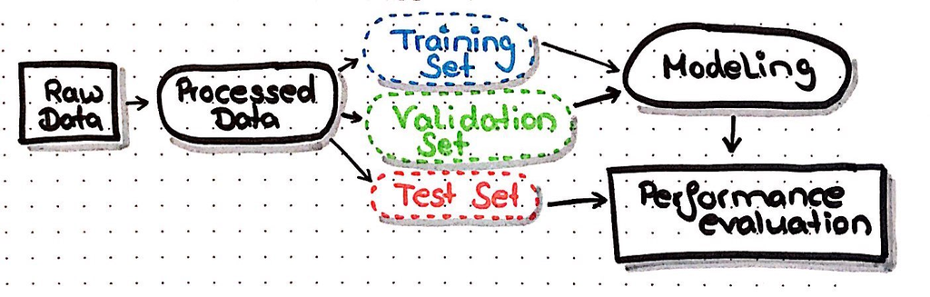

Current machine learning algorithms’ performance depends heavily on the features given as inputs. Choosing or engineering the correct feature representation for modeling is still a task that needs expert domain knowledge and experience in data handling and transformation techniques, like normalization.

Moreover, we want our model to balance generalization and specificity. Achieving good generalization is the difficult part! Test data bleeds into training data if we use it to compare models. Therefore, we use validation sets for choosing a model and only use the test data in the final step to assess quality! Cross-validation is usually used to prevent over-fitting on smaller data sets because you don’t have enough data for hold-out validation sets to be effective. The bigger the validation set, the more precise the numbers we get from the model.

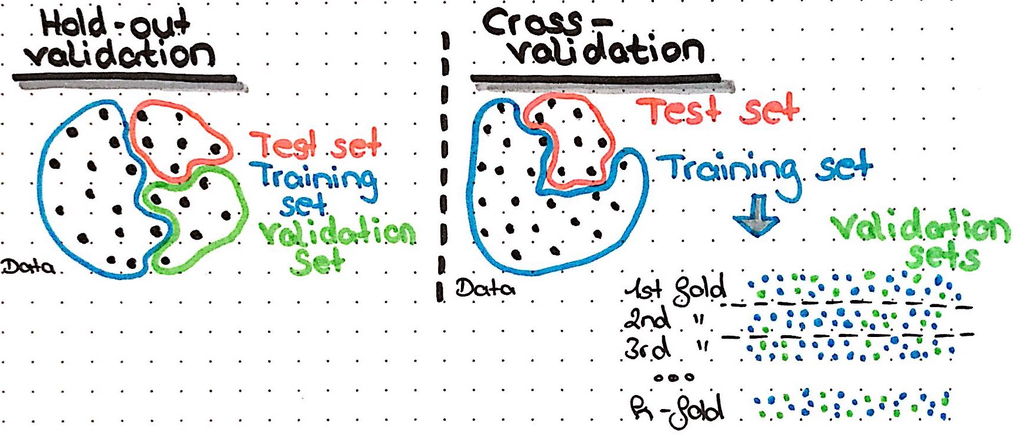

# Deep learning

Deep learning is a family of machine learning techniques that is used wherever there is large amounts of data (“Big Data”) and very complex problems to solve. Examples are speech recognition, image classification, natural language processing, object recognition, etc. Deep learning is loosely defined as neural networks with more two hidden layers. This allows the model to learn abstract non-linear combinations of features that represent the underlying pattern of the data.

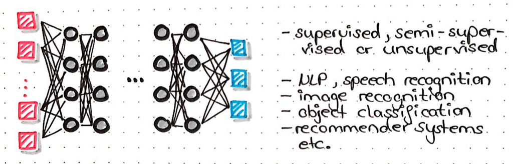

# Practical Part

## Keras & TensorFlow

Here, we’ll be using Keras on top of TensorFlow.

> “TensorFlow™ is an open source software library for numerical computation using data flow graphs. Nodes in the graph represent mathematical operations, while the graph edges represent the multidimensional data arrays (tensors) communicated between them. The flexible architecture allows you to deploy computation to one or more CPUs or GPUs in a desktop, server, or mobile device with a single API. TensorFlow was originally developed by researchers and engineers working on the Google Brain Team within Google’s Machine Intelligence research organization for the purposes of conducting machine learning and deep neural networks research, but the system is general enough to be applicable in a wide variety of other domains as well.” https://www.tensorflow.org/

[figure not shown]

## Tensors

In Machine Learning, tensors are described as multi-dimensional arrays; they can be scalars, vectors, matrices, etc. BUT mathematically speaking, this isn’t technically correct. Tensors are actually multi-linear functions, while multi-dimensional arrays are data structures. Multi-dimensional arrays can represent tensors!

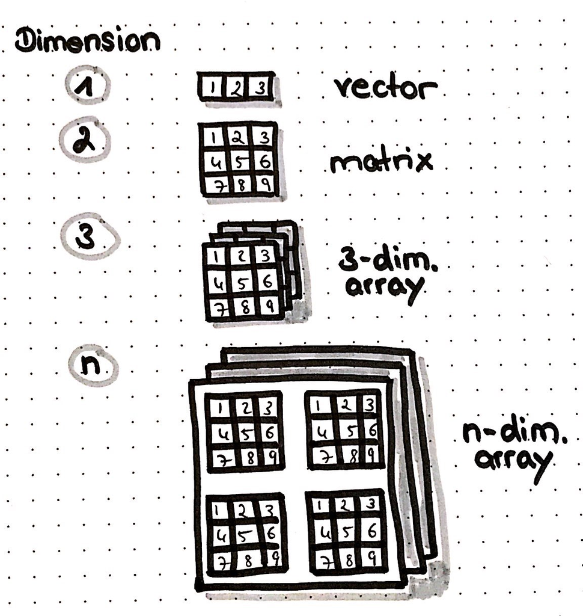

## Graphs

TensorFlow uses computational graphs to represent operations: Each node takes zero or more tensors as inputs and performs a mathematical operation to produce a tensor as an output. You can easily visualize model graphs you trained with TensorFlow via [TensorBoard](https://www.tensorflow.org/get_started/summaries_and_tensorboard)

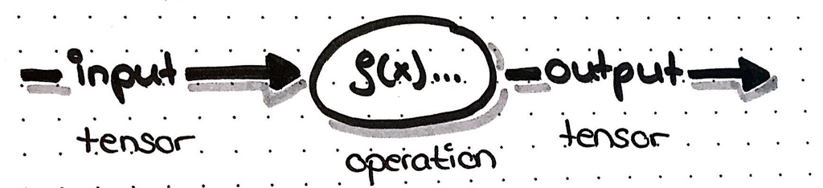

## Convolutional Neural Networks (CNNs)

CNNs are a class of deep neural networks that are most commonly used in image recognition, NLP and recommender systems. They are different compared to “normal” neural networks in that each neuron connects only to a part of the neurons in subsequent layers, not to all of them. This is similar to the visual cortex in the human brain where stimuli neurons stimulate a specific region of the visual field, called the receptive field. Another characteristic that CNNs have in common with the visual cortex is that the stimulated regions of neighboring neurons partially overlap, so that the entire visual field or image is covered. The advantage that CNNs have over regular neural networks is that they are not fully connected and share weights and biases; therefore they can be much deeper (i.e. have many hidden layers) without becoming excessively large, as a very deep dense network would.

Just like a regular neural network, we have an input layer, multiple hidden layers and an output layer. The magic happens in the hidden layers, which are a combination of convolutional layers, pooling layers and dense (fully connected) layers.

- **Convolution:**

Convolution layers process the inputs of subsets of neurons, just like described above, and pass the output on to the next subset of neurons in subsequent layers. The convolution process calculates an activation map for each region that will be triggered if the learned network recognizes a typical feature used for classification.

- **Pooling:**

Pooling layers combine the stacked outputs (i.e. the activation maps) of all subsets of neurons from preceding convolutional layers. Pooling layers can be distributed throughout convolutional layers or they can be put behind all convolutional layers in a network. Convolution and pooling layers are typically followed by a set of dense layers before the final output layer.

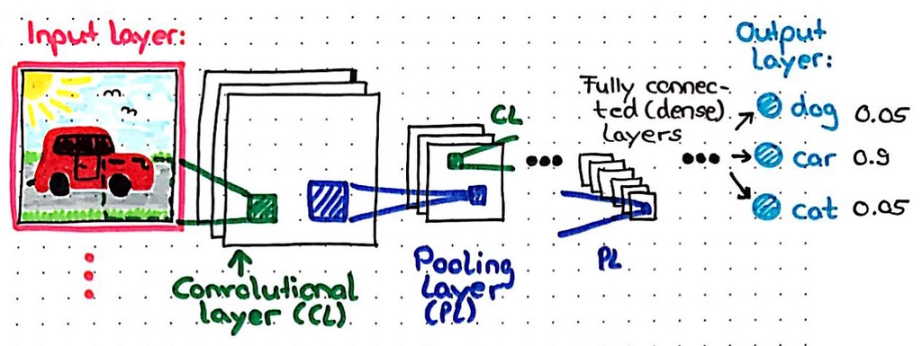